# climate_ordination

Trisha Gopalakrishna

24/05/2021

```r
library(RColorBrewer)
library(lattice)
library(raster)
library(sf)
library(terra)
library(tmap)

library(tidyverse)
```

```r
library(dplyr)

library(ggplot2)

library(viridis)
terraOptions(memfrac=0.5, tempdir = "C://Users//Trisha_Gopalakrishna//OneDrive - Nexus365//Paper2//Scratch",
             progress=10)
rasterOptions(overwrite = TRUE, tmpdir = "C://Users//Trisha_Gopalakrishna//OneDrive - Nexus365//Paper2//Scratch",
              tmptime = 2, progress="window", timer = TRUE,chunksize = 2e+07, maxmemory = 1e+09)
memory.limit(size=20000)
```

```
## [1] 20000
```

## Introduction

Based on Yadvinder and Sami’s suggestion in the May meeting of the Indian savannah study, I am going to use ordination techniques to reduce the climate variables to 2 variables max in this script. I will start first with doing Principle Component Analyses (PCA), then Nonmetric Multidimensional Scaling (NMDS) and then Linear Discriminant Funciton Analysis (LDF) only on the climate data for now. Will probably do similar analyses on the herbivory data too.

###1. Data input

```r
data_df<-read.csv("C://Users//Trisha_Gopalakrishna//OneDrive - Nexus365//Paper2//Output//Sampled_Data//cleanedx100mm_data.csv")
head(data_df)
```

```
##   X Aridity_studyarea BinaryBurn BuffaloDM BurnFreq  CattleDM DrySeasonLength
## 1 1         0.1587989          0  6.329967        0  6.925442        11.36667
## 2 2         0.1510802          0  6.329967        0  6.925442        11.40000
## 3 3         0.1398965          0  6.329967        0  6.925442        11.43333
## 4 4         0.1363891          0  6.329967        0  6.925442        11.53333
## 5 5         0.4180445          0  9.041696        0 29.708931         9.70000
## 6 6         0.3067597          0 31.319799        0 32.537163        10.40000
##   DrySeasonRainfall   GoatDM    HorseDM       MAP       MCWD   Sandfrac
## 1         0.1467831 1.037885 0.06682350 0.2822586 -1066.1895  1.1745780
## 2         0.1449593 1.037885 0.06682350 0.2767940 -1082.2429  0.2275994
## 3         0.1456207 1.037885 0.06682350 0.2761891  -881.5046  4.4894366
## 4         0.1588239 1.037885 0.06682350 0.2770771  -815.9875 11.3335848
## 5         0.2304967 2.354265 0.06567515 0.6967920  -735.5171  8.6405401
## 6         0.2355853 3.643748 0.06880965 0.6744267  -617.4921 25.6387177
##    SheepDM      VPD WaterHoldingCap Percent_NonTree_Vegetation_mean
## 1 1.521289 1.278547        2.216021                        11.65902
## 2 1.521289 1.486266        2.614755                        10.29754
## 3 1.521289 1.510835        2.643904                        10.90814
## 4 1.521289 1.627678        4.415808                        10.94298
## 5 1.456063 1.563860       14.250332                        66.95103
## 6 0.515959 1.679217       17.582554                        68.54356
##   Percent_NonVegetated_mean Percent_Tree_Cover_mean    x    y
## 1                  86.03966               2.3013234 69.0 24.0
## 2                  86.75686               2.9456036 69.1 24.0
## 3                  88.52464               0.5672131 69.0 24.1
## 4                  88.84521               0.2118155 69.1 24.1
## 5                  22.19593              10.8530378 75.3 19.5
## 6                  27.17737               4.2790651 75.5 24.8
```

```r
summary(data_df)
```

```
##        X       Aridity_studyarea   BinaryBurn        BuffaloDM
##  Min.   :  1   Min.   :0.05335   Min.   :0.00000   Min.   :  0.000
##  1st Qu.:210   1st Qu.:0.23069   1st Qu.:0.00000   1st Qu.:  5.382
##  Median :419   Median :0.35612   Median :0.00000   Median : 11.008
##  Mean   :419   Mean   :0.46891   Mean   :0.03226   Mean   : 20.149
##  3rd Qu.:628   3rd Qu.:0.52972   3rd Qu.:0.00000   3rd Qu.: 24.591
##  Max.   :837   Max.   :8.03685   Max.   :1.00000   Max.   :252.779
##     BurnFreq           CattleDM        DrySeasonLength  DrySeasonRainfall
##  Min.   : 0.00000   Min.   :  0.7889   Min.   : 0.000   Min.   :0.0000
##  1st Qu.: 0.00000   1st Qu.: 14.0823   1st Qu.: 8.867   1st Qu.:0.2680
##  Median : 0.00000   Median : 23.2258   Median : 9.933   Median :0.3224
##  Mean   : 0.06332   Mean   : 30.3686   Mean   : 9.721   Mean   :0.3652
##  3rd Qu.: 0.00000   3rd Qu.: 36.1066   3rd Qu.:11.000   3rd Qu.:0.4218
##  Max.   :10.00000   Max.   :653.9396   Max.   :12.000   Max.   :1.4412
##      GoatDM            HorseDM              MAP               MCWD
##  Min.   : 0.01436   Min.   :0.000049   Min.   : 0.1477   Min.   :-1082.2
##  1st Qu.: 1.10680   1st Qu.:0.013340   1st Qu.: 0.6973   1st Qu.: -307.0
##  Median : 2.16423   Median :0.040476   Median : 0.9926   Median : -208.0
##  Mean   : 2.95777   Mean   :0.102879   Mean   : 1.1478   Mean   : -218.5
##  3rd Qu.: 3.69349   3rd Qu.:0.091679   3rd Qu.: 1.3771   3rd Qu.: -109.9
##  Max.   :32.57362   Max.   :4.425928   Max.   :13.0998   Max.   :    0.0
##     Sandfrac           SheepDM               VPD         WaterHoldingCap
##  Min.   : 0.04942   Min.   : 0.000008   Min.   :0.1424   Min.   : 0.4324
##  1st Qu.:24.86426   1st Qu.: 0.111953   1st Qu.:1.0900   1st Qu.:23.5616
##  Median :32.93181   Median : 0.610349   Median :1.4947   Median :27.2075
##  Mean   :32.55698   Mean   : 1.997359   Mean   :1.4213   Mean   :27.1197
##  3rd Qu.:39.15242   3rd Qu.: 2.331166   3rd Qu.:1.7539   3rd Qu.:32.8010
##  Max.   :64.87291   Max.   :20.420324   Max.   :2.5224   Max.   :44.8908
##  Percent_NonTree_Vegetation_mean Percent_NonVegetated_mean
##  Min.   : 5.636                  Min.   : 1.607
##  1st Qu.:56.927                  1st Qu.:15.858
##  Median :68.128                  Median :21.276
##  Mean   :61.518                  Mean   :26.815
##  3rd Qu.:72.520                  3rd Qu.:29.803
##  Max.   :80.178                  Max.   :94.364
##  Percent_Tree_Cover_mean       x               y
##  Min.   : 0.00022        Min.   :68.30   Min.   : 8.6
##  1st Qu.: 3.83282        1st Qu.:74.90   1st Qu.:19.6
##  Median : 7.27624        Median :77.90   Median :23.1
##  Mean   :11.66730        Mean   :79.11   Mean   :22.6
##  3rd Qu.:11.63911        3rd Qu.:82.60   3rd Qu.:26.1
##  Max.   :78.70403        Max.   :96.40   Max.   :34.3
```

```r
data_df_climate<- data_df %>% dplyr::select(Aridity_studyarea, DrySeasonLength, DrySeasonRainfall,
                                        MAP, MCWD, VPD, BinaryBurn)

head(data_df_climate)
```

```
##   Aridity_studyarea DrySeasonLength DrySeasonRainfall       MAP       MCWD
## 1         0.1587989        11.36667         0.1467831 0.2822586 -1066.1895
## 2         0.1510802        11.40000         0.1449593 0.2767940 -1082.2429
## 3         0.1398965        11.43333         0.1456207 0.2761891  -881.5046
## 4         0.1363891        11.53333         0.1588239 0.2770771  -815.9875
## 5         0.4180445         9.70000         0.2304967 0.6967920  -735.5171
## 6         0.3067597        10.40000         0.2355853 0.6744267  -617.4921
##        VPD BinaryBurn
## 1 1.278547          0
## 2 1.486266          0
## 3 1.510835          0
## 4 1.627678          0
## 5 1.563860          0
## 6 1.679217          0
```

```r
names(data_df_climate)[1]<-"Aridity"

data_df_herbivory<- data_df %>% dplyr:: select(BinaryBurn, BuffaloDM, CattleDM, GoatDM, HorseDM, SheepDM)
head(data_df_herbivory)
```

```
##   BinaryBurn BuffaloDM  CattleDM   GoatDM    HorseDM  SheepDM
## 1          0  6.329967  6.925442 1.037885 0.06682350 1.521289
## 2          0  6.329967  6.925442 1.037885 0.06682350 1.521289
## 3          0  6.329967  6.925442 1.037885 0.06682350 1.521289
## 4          0  6.329967  6.925442 1.037885 0.06682350 1.521289
## 5          0  9.041696 29.708931 2.354265 0.06567515 1.456063
## 6          0 31.319799 32.537163 3.643748 0.06880965 0.515959
```

###2. PCA Assumptions- check for linearity and multinormality.

```r
head(data_df_climate)
```

```
##     Aridity DrySeasonLength DrySeasonRainfall       MAP       MCWD      VPD
## 1 0.1587989        11.36667         0.1467831 0.2822586 -1066.1895 1.278547
## 2 0.1510802        11.40000         0.1449593 0.2767940 -1082.2429 1.486266
## 3 0.1398965        11.43333         0.1456207 0.2761891  -881.5046 1.510835
## 4 0.1363891        11.53333         0.1588239 0.2770771  -815.9875 1.627678
## 5 0.4180445         9.70000         0.2304967 0.6967920  -735.5171 1.563860
## 6 0.3067597        10.40000         0.2355853 0.6744267  -617.4921 1.679217
##   BinaryBurn
## 1          0
## 2          0
## 3          0
## 4          0
## 5          0
## 6          0
```

```r
str(data_df_climate)
```

```
## 'data.frame':    837 obs. of  7 variables:
##  $ Aridity          : num  0.159 0.151 0.14 0.136 0.418 ...
##  $ DrySeasonLength  : num  11.4 11.4 11.4 11.5 9.7 ...
##  $ DrySeasonRainfall: num  0.147 0.145 0.146 0.159 0.23 ...
##  $ MAP              : num  0.282 0.277 0.276 0.277 0.697 ...
##  $ MCWD             : num  -1066 -1082 -882 -816 -736 ...
##  $ VPD              : num  1.28 1.49 1.51 1.63 1.56 ...
##  $ BinaryBurn       : int  0 0 0 0 0 0 0 0 0 0 ...
```

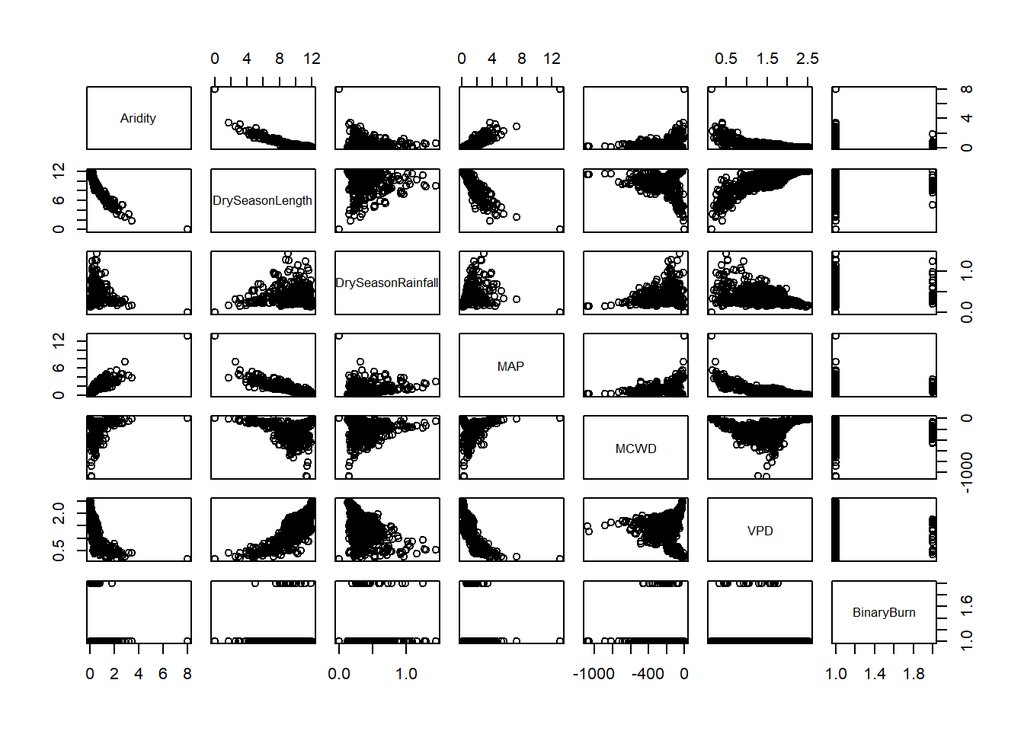

```r
data_df_climate$BinaryBurn<- as.factor(data_df_climate$BinaryBurn)

pairs(data_df_climate)
```

```r
data_df_climate_pivot<- data_df_climate %>% pivot_longer(1:6)
head(data_df_climate_pivot)
```

```
## # A tibble: 6 x 3
##   BinaryBurn name                  value
##   <fct>      <chr>                 <dbl>
## 1 0          Aridity               0.159
## 2 0          DrySeasonLength      11.4
## 3 0          DrySeasonRainfall     0.147
## 4 0          MAP                   0.282
## 5 0          MCWD              -1066.
## 6 0          VPD                   1.28
```

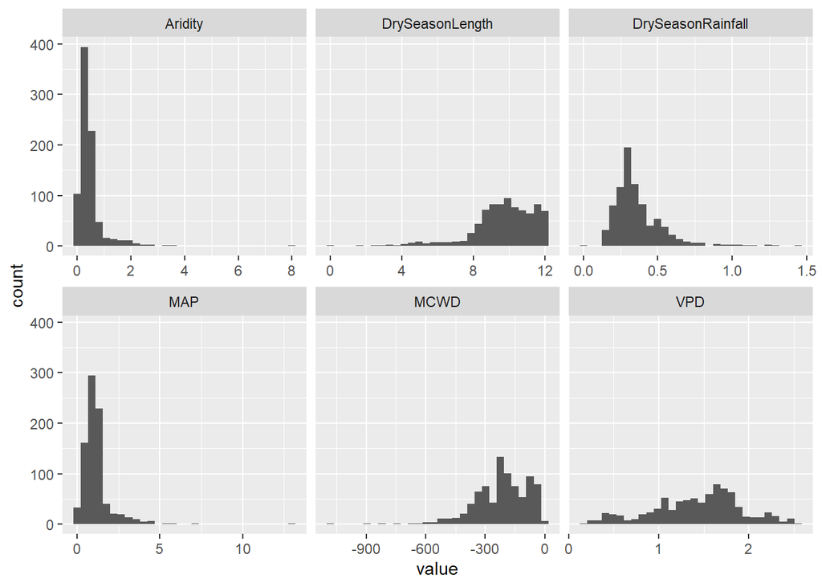

```r
ggplot(data_df_climate_pivot, aes(x=value))+
  geom_histogram()+
  facet_wrap(~ name, scales= "free_x")
```

```r
data_df_herbivory$BinaryBurn<- as.factor(data_df_herbivory$BinaryBurn)
data_df_herbivory_pivot<- data_df_herbivory %>% pivot_longer(2:6)
head(data_df_herbivory_pivot)
```

```
## # A tibble: 6 x 3
##   BinaryBurn name       value
##   <fct>      <chr>      <dbl>
## 1 0          BuffaloDM 6.33
## 2 0          CattleDM  6.93
## 3 0          GoatDM    1.04
## 4 0          HorseDM   0.0668
## 5 0          SheepDM   1.52
## 6 0          BuffaloDM 6.33
```

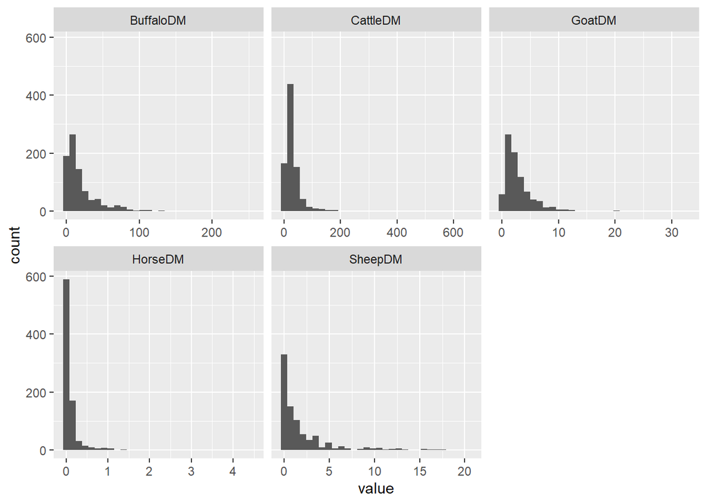

```r
ggplot(data_df_herbivory_pivot, aes(x=value))+
  geom_histogram()+
  facet_wrap(~ name, scales= "free_x")
```

Linearity and normality assumptions are violated.

```r
climate.pca<- data_df_climate %>%
  dplyr::select(1:6) %>%
  stats::prcomp(scale.= TRUE, center= TRUE)

climate.pca %>% summary()
```

```
## Importance of components:
##                           PC1    PC2    PC3     PC4     PC5     PC6
## Standard deviation     1.8615 1.0850 0.9967 0.47691 0.28546 0.23561
## Proportion of Variance 0.5775 0.1962 0.1656 0.03791 0.01358 0.00925
## Cumulative Proportion  0.5775 0.7737 0.9393 0.97717 0.99075 1.00000
```

```r
climate.pca$rotation
```

```
##                           PC1          PC2         PC3        PC4         PC5
## Aridity            0.49591038 -0.186382299  0.21285293 -0.3192461  0.51931765
## DrySeasonLength   -0.50786161  0.187338557 -0.01179557 -0.2597168  0.73379892
## DrySeasonRainfall  0.10951742  0.822858691 -0.37166149 -0.2874123 -0.12347034
## MAP                0.51232989 -0.007733314  0.06812578 -0.5102664 -0.11624265
## MCWD               0.02588709  0.465701710  0.85887712  0.2033990 -0.03531782
## VPD               -0.47010994 -0.190083115  0.27223374 -0.6680421 -0.40229802
##                           PC6
## Aridity            0.54992661
## DrySeasonLength   -0.31769175
## DrySeasonRainfall  0.27372704
## MAP               -0.67744591
## MCWD              -0.04651188
## VPD                0.24623132
```

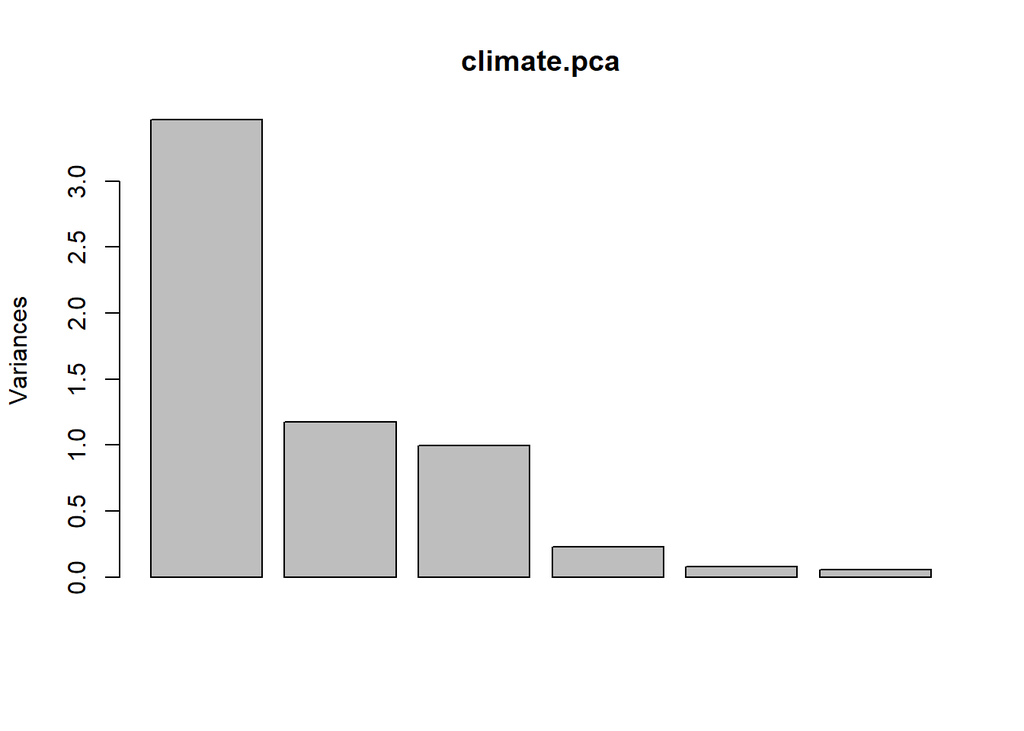

```r
plot(climate.pca)
```

```r
herbivory.pca<- data_df_herbivory %>%
  dplyr::select(2:6) %>%
  stats::prcomp(scale.= TRUE, center= TRUE)

herbivory.pca %>% summary()
```

```
## Importance of components:
##                          PC1    PC2    PC3    PC4     PC5
## Standard deviation     1.330 1.0615 1.0028 0.8798 0.56883
## Proportion of Variance 0.354 0.2254 0.2011 0.1548 0.06471
## Cumulative Proportion  0.354 0.5794 0.7805 0.9353 1.00000
```

```r
herbivory.pca$rotation
```

```
##                   PC1        PC2        PC3        PC4         PC5
## BuffaloDM  0.06585398 -0.7551805  0.3059181 -0.5736554  0.05195515
## CattleDM  -0.67249460  0.1116205  0.1041183 -0.1037048  0.71672629
## GoatDM    -0.60090434  0.1008235 -0.3109683 -0.4214607 -0.59533035
## HorseDM   -0.42354343 -0.3712735  0.4241416  0.6383511 -0.30883441
## SheepDM   -0.05421449 -0.5188775 -0.7867504  0.2739409  0.18386725
```

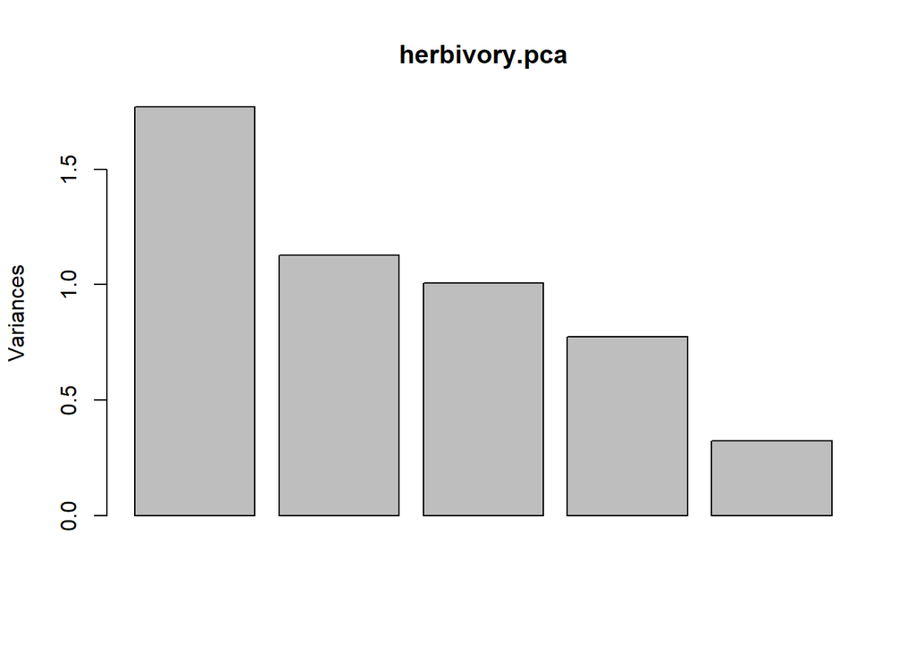

```r
plot(herbivory.pca)
```

First 2 components explain 77.3% of the variance with PCA 1 explaining 57.7% of the variance in the data (see screeplot below).

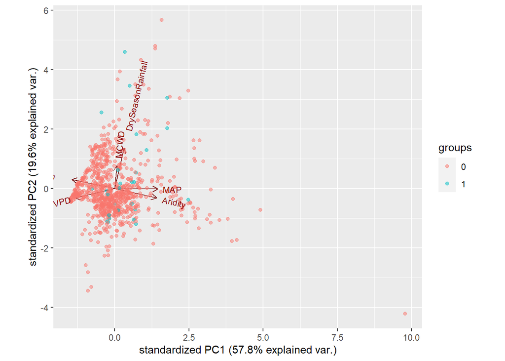

```r
#library(devtools)
#devtools::install_github("vqv/ggbiplot")
library(ggbiplot)
climate.pca %>%
  ggbiplot::ggbiplot(alpha=0.5, groups=data_df_climate$BinaryBurn)
```

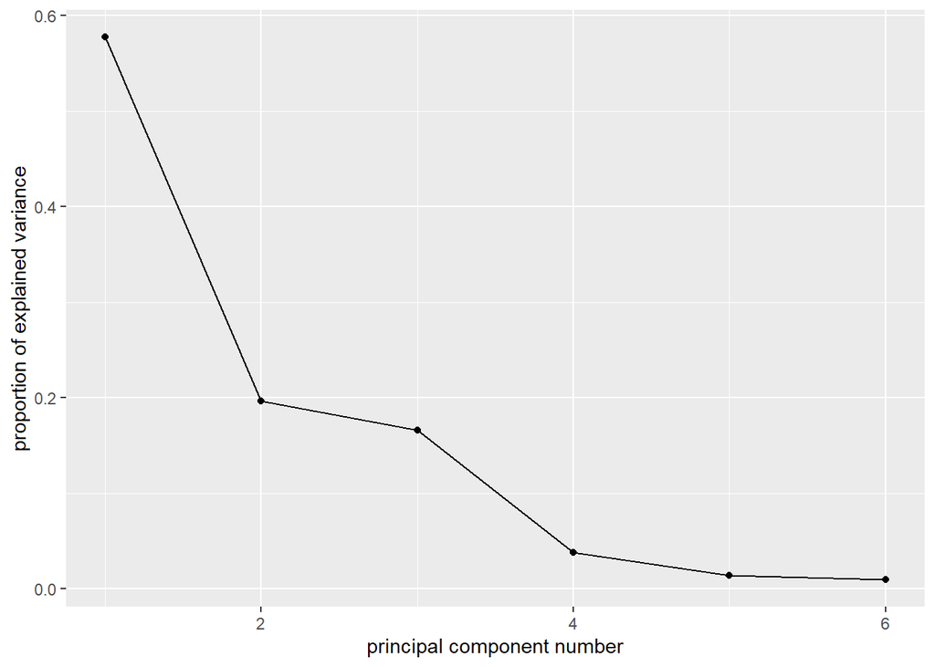

```r
climate.pca %>%
  ggbiplot::ggscreeplot()
```

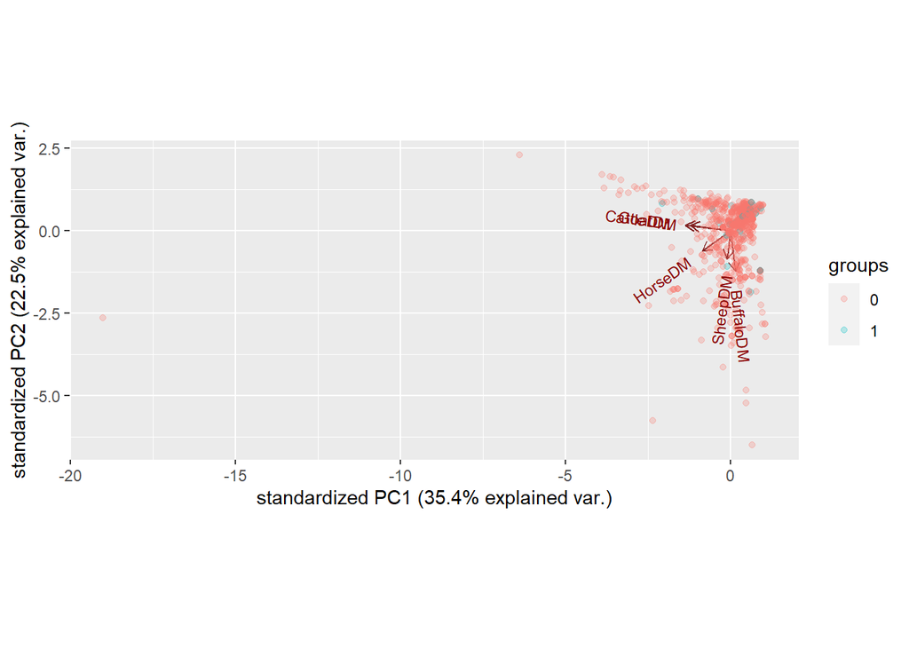

```r
herbivory.pca %>%
  ggbiplot::ggbiplot(alpha=0.25, groups=data_df_herbivory$BinaryBurn)
```

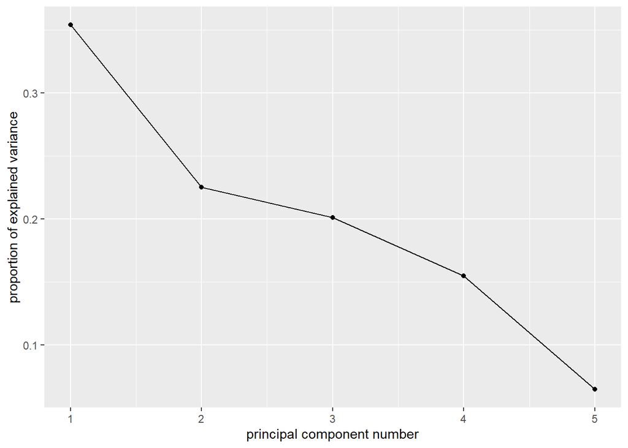

```r
herbivory.pca %>%
  ggbiplot::ggscreeplot()
```

Biplot shows that MCWD and dry season rainfall might be positively correlated (small angle between the two vectors). MAP and aridity index also seem to be correlated positively.

Biplot shows that cattle and goat DM are positively correlated. So is Buffalo and sheep DM.